# Eelgrass Carbon Stock

Tsawwassen Beach, BC (worked example)

Published

August 26, 2026

## 1 The headline

| Quantity | Value |
| --- | --- |
| Carbon stock to 25 cm (measured) | 31.4 ± 2.7 Mg C/ha |
| Carbon stock to 50 cm (partly modelled) | 51.5 ± 3.8 Mg C/ha |
| After combining with the regional prior | 30.4 ± 2.6 Mg C/ha |
| Site total to 25 cm | 157 Mg C over 5.0 ha |
| Precision achieved | ±18.6% at 90% confidence |
| Precision target | ±10% — NOT met |

The campaign did not reach its precision target. That is a result, not a failure — it says the interval is too wide to manage by, and the analysis below shows what would close it.

## 2 What was collected

6 cores across 2 strata, 32 sediment slices.

| Core | Stratum | Stock 0-25 cm (kg C/m²) | Stock 0-50 cm (kg C/m²) | % modelled |
| --- | --- | --- | --- | --- |
| WWF-01-A | SM | 5.35 | 9.06 | 0.0 |
| WWF-01-B | SG | 1.96 | 3.08 | 29.3 |
| WWF-01-C | SM | 5.48 | 9.46 | 0.0 |
| WWF-01-D | SM | 4.68 | 7.77 | 0.0 |
| WWF-01-E | SG | 2.73 | 4.05 | 19.5 |
| WWF-01-F | SG | 1.33 | 2.23 | 38.8 |

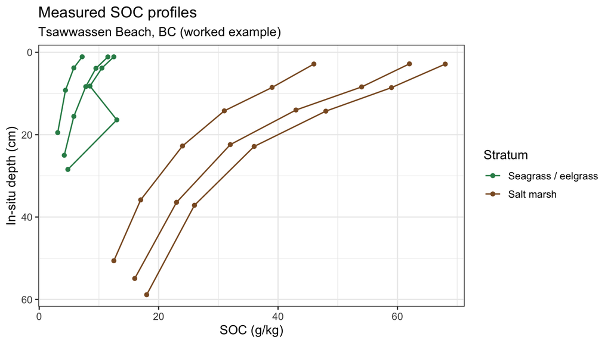

## 3 Compaction

A percussion corer compresses sediment: you recover a shorter core than the hole you made. Correcting for it restores the original depths — and must leave the carbon unchanged, because the tube holds exactly what came out of the ground. The depths stretch by the compaction factor and the bulk density thins by the same factor, so the two cancel.

| Core | Compaction factor | In-situ depth (cm) |
| --- | --- | --- |
| WWF-01-A | 1.121 | 65 |
| WWF-01-B | 1.111 | 30 |
| WWF-01-C | 1.143 | 72 |
| WWF-01-D | 1.137 | 58 |
| WWF-01-E | 1.094 | 35 |
| WWF-01-F | 1.083 | 26 |

## 4 Putting cores on common depths

Cores reach different depths and were sliced at different thicknesses, so they are splined onto standard intervals with a mass-preserving spline (`mpspline2`). Below the base of a core the profile is **modelled**, not measured, using an asymptotic curve with a non-zero recalcitrant floor.

Every interval records how much of it is measured rather than modelled, and stocks are apportioned by that fraction — so a core ending at 26 cm contributes only its real 4% to the 25–50 cm interval.

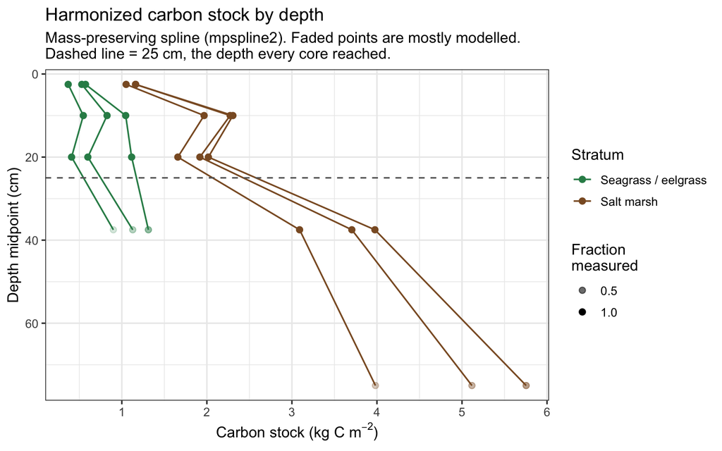

## 5 The estimate

Each stratum’s mean is weighted by its **area**, not by how many cores landed in it, using a design-based stratified estimator (`survey`) with a finite population correction.

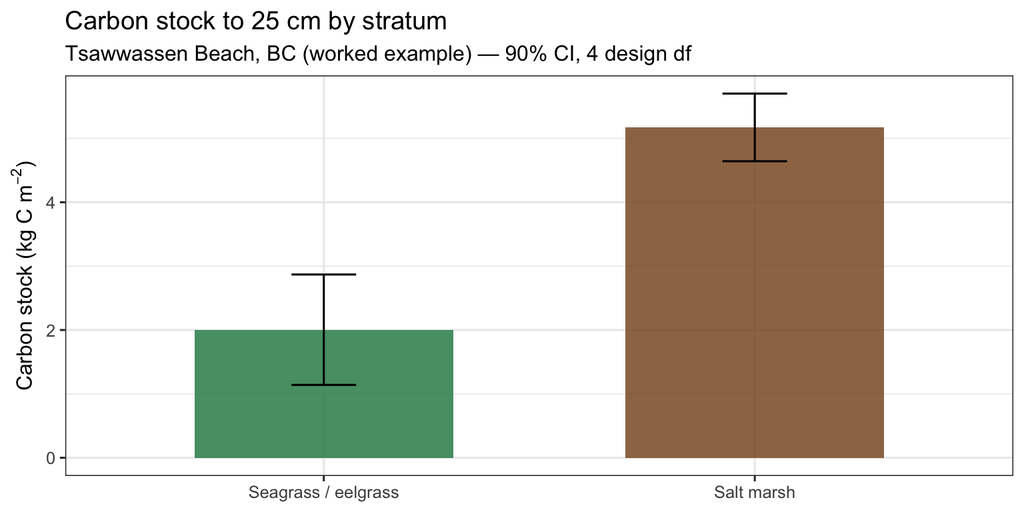

| Stratum | Mean 0-25 cm (kg C/m²) | SE |
| --- | --- | --- |
| Seagrass / eelgrass | 2.00 | 0.41 |
| Salt marsh | 5.17 | 0.25 |

The interval rests on **4 degrees of freedom**. With this few cores it is wide, and no amount of analysis narrows it — only more cores, or a looser target, will.

## 6 Combining with what was already known

The planning stage used a prior to size the campaign. That prior is still true afterwards, so it is used again here as evidence — a weighted average, where each source contributes in proportion to its precision.

The prior comes from 82 *Zostera marina* cores across 11 estuaries in the Janousek et al. (2025) synthesis, filtered to sites that resemble this one and **excluding this site’s own cores**, which appear in that synthesis and would otherwise be counted twice.

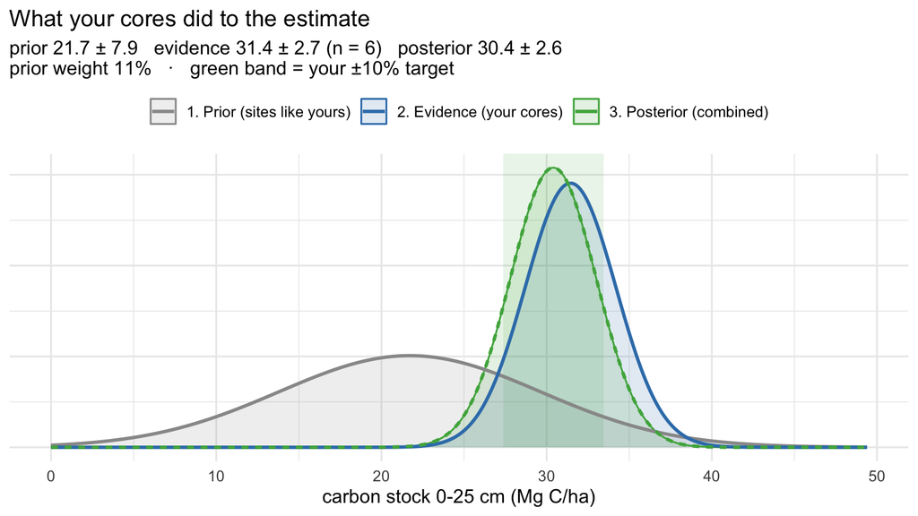

| Source | Mg C/ha | Weight |
| --- | --- | --- |
| Prior (sites like this one) | 21.7 ± 7.9 | 11% |
| Evidence (these cores) | 31.4 ± 2.7 | 89% |
| Posterior (combined) | 30.4 ± 2.6 | — |

The prior earned **11%** of the weight. Most of the answer comes from the fieldwork, which is what a campaign of this size should produce.

## 7 What to be careful about

- **The deep number is partly modelled.** Below each core’s base the profile is an extrapolation, and the per-core modelled share is in the table above.
- **4 degrees of freedom** is very few. The confidence interval is honest but wide, and the between-stratum comparison has low power — a non-significant result there is not evidence the strata are equal.
- **Stratum areas drive the site total.** They come from `STRATUM_AREAS_M2` in `00_config.R`; if those are placeholders, so is the total.
- **The prior assumes independence.** It excludes this site’s own cores. If you move this workflow to another meadow, check `PRIOR_EXCLUDE_ESTUARY` again.
- **No map here.** Mapping where the carbon sits needs far more cores than this — see `06_advanced_spatial.R`.

## 8 Methods

| Step | Method | Source |
| --- | --- | --- |
| Compaction | Depth stretch with matching bulk-density correction | from scratch — matches the digital data sheet |
| Depth harmonization | Mass-preserving (equal-area) spline | **mpspline2** — Bishop et al. (1999); Malone et al. (2009) |
| Below-core profile | Asymptotic model with a non-zero recalcitrant floor | base **stats** `SSasymp` — shape after Kindeberg et al. (2019) |
| Stratified estimation | Design-based stratified mean with finite population correction | **survey** — Lumley (2004, 2010); Cochran (1977) |
| Prior | Similarity-matched subset of a regional core synthesis | Janousek et al. (2025), figshare 28127486 |
| Combination | Normal-Normal precision-weighted update | from scratch — Gelman et al. (2013) §2.5 |

*Generated 2026-08-26 from the pipeline in this folder. Every number above is produced by `run_pipeline.R`; this report contains no separate calculation.*